# JSC370 Homework 1 - Yibing Xia

Author

Yibing Xia

```python
import pandas as pd
import numpy as np
from plotnine import *
import warnings
warnings.filterwarnings('ignore')
import matplotlib.pyplot as plt
import folium
from folium.plugins import MarkerCluster
import statsmodels.api as sm
from scipy import stats
```

# Primary Question

What are the most numerous categories of crimes and offences in Toronto? Of these, when and where are they most likely to occur?

# Data Source

Toronto Police Department Public Safety Data Portal - Major Crime Indicators Open Data

## 1. Read in the data (3 points)

```python
# Read the dataset into Python
crime = pd.read_csv('Major_Crime_Indicators_Open_Data_-3805566126367379926.csv')

# The key variables in the instructions are defined here, but for the purpose of
# exploration and reporting dataset dimension, dataset subsetting is done in task 2.
key_vars = ['MCI_CATEGORY', 'OFFENCE', 'OCC_YEAR','OCC_MONTH', 'OCC_DAY', 'OCC_DOY',
            'OCC_HOUR','LOCATION_TYPE', 'NEIGHBOURHOOD_158', 'LONG_WGS84',
            'LAT_WGS84']

crime.head()
```

|  | OBJECTID | EVENT_UNIQUE_ID | REPORT_DATE | OCC_DATE | REPORT_YEAR | REPORT_MONTH | REPORT_DAY | REPORT_DOY | REPORT_DOW | REPORT_HOUR | ... | OFFENCE | MCI_CATEGORY | HOOD_158 | NEIGHBOURHOOD_158 | HOOD_140 | NEIGHBOURHOOD_140 | LONG_WGS84 | LAT_WGS84 | x | y |
| --- | --- | --- | --- | --- | --- | --- | --- | --- | --- | --- | --- | --- | --- | --- | --- | --- | --- | --- | --- | --- | --- |
| 0 | 1 | GO-20141261013 | 1/1/2014 5:00:00 AM | 1/1/2014 5:00:00 AM | 2014 | January | 1 | 1 | Wednesday | 4 | ... | Assault | Assault | 155 | Downsview (155) | 026 | Downsview-Roding-CFB (26) | -79.483869 | 43.734369 | -8.848104e+06 | 5.424427e+06 |
| 1 | 2 | GO-20141261561 | 1/1/2014 5:00:00 AM | 1/1/2014 5:00:00 AM | 2014 | January | 1 | 1 | Wednesday | 8 | ... | Assault With Weapon | Assault | 154 | Oakdale-Beverley Heights (154) | 026 | Downsview-Roding-CFB (26) | -79.513772 | 43.719813 | -8.851433e+06 | 5.422185e+06 |
| 2 | 3 | GO-20141262377 | 1/1/2014 5:00:00 AM | 1/1/2014 5:00:00 AM | 2014 | January | 1 | 1 | Wednesday | 12 | ... | Assault Bodily Harm | Assault | 068 | North Riverdale (68) | 068 | North Riverdale (68) | -79.357562 | 43.674791 | -8.834043e+06 | 5.415253e+06 |
| 3 | 4 | GO-20141262553 | 1/1/2014 5:00:00 AM | 1/1/2014 5:00:00 AM | 2014 | January | 1 | 1 | Wednesday | 14 | ... | Assault | Assault | 094 | Wychwood (94) | 094 | Wychwood (94) | -79.422371 | 43.673842 | -8.841258e+06 | 5.415106e+06 |
| 4 | 5 | GO-20141263115 | 1/1/2014 5:00:00 AM | 1/1/2014 5:00:00 AM | 2014 | January | 1 | 1 | Wednesday | 16 | ... | Assault | Assault | 120 | Clairlea-Birchmount (120) | 120 | Clairlea-Birchmount (120) | -79.286725 | 43.700100 | -8.826158e+06 | 5.419149e+06 |

5 rows × 31 columns

```python
display(crime.shape) # Dataset dimension
display(crime.dtypes) # Variable names and types
display(crime.isnull().sum()) # Number of missing data
```

```
(452949, 31)
```

```
OBJECTID               int64
EVENT_UNIQUE_ID       object
REPORT_DATE           object
OCC_DATE              object
REPORT_YEAR            int64
REPORT_MONTH          object
REPORT_DAY             int64
REPORT_DOY             int64
REPORT_DOW            object
REPORT_HOUR            int64
OCC_YEAR             float64
OCC_MONTH             object
OCC_DAY              float64
OCC_DOY              float64
OCC_DOW               object
OCC_HOUR               int64
DIVISION              object
LOCATION_TYPE         object
PREMISES_TYPE         object
UCR_CODE               int64
UCR_EXT                int64
OFFENCE               object
MCI_CATEGORY          object
HOOD_158              object
NEIGHBOURHOOD_158     object
HOOD_140              object
NEIGHBOURHOOD_140     object
LONG_WGS84           float64
LAT_WGS84            float64
x                    float64
y                    float64
dtype: object
```

```
OBJECTID               0
EVENT_UNIQUE_ID        0
REPORT_DATE            0
OCC_DATE               0
REPORT_YEAR            0
REPORT_MONTH           0
REPORT_DAY             0
REPORT_DOY             0
REPORT_DOW             0
REPORT_HOUR            0
OCC_YEAR             151
OCC_MONTH            151
OCC_DAY              151
OCC_DOY              151
OCC_DOW              151
OCC_HOUR               0
DIVISION               0
LOCATION_TYPE          0
PREMISES_TYPE          0
UCR_CODE               0
UCR_EXT                0
OFFENCE                0
MCI_CATEGORY           0
HOOD_158               0
NEIGHBOURHOOD_158      0
HOOD_140               0
NEIGHBOURHOOD_140      0
LONG_WGS84             0
LAT_WGS84              0
x                      0
y                      0
dtype: int64
```

```python
# From the dtypes output, we see that month is objects.
# Convert month names to numbers
month_map = {
    'January': 1, 'February': 2, 'March': 3, 'April': 4,
    'May': 5, 'June': 6, 'July': 7, 'August': 8,
    'September': 9, 'October': 10, 'November': 11, 'December': 12
}
crime['OCC_MONTH'] = crime['OCC_MONTH'].map(month_map)

# Convert other temporal variables to numeric
temporal_cols = ['OCC_YEAR', 'OCC_DAY', 'OCC_DOY', 'OCC_HOUR']
for col in temporal_cols:
    crime[col] = pd.to_numeric(crime[col], errors='coerce')
```

```python
# Replace "Unknown" values with NaN
crime = crime.replace('Unknown', np.nan)

# Display updated null counts
print("Updated missing data counts after replacing 'Unknown':")
display(crime.isnull().sum())
```

```
Updated missing data counts after replacing 'Unknown':
```

```
OBJECTID                0
EVENT_UNIQUE_ID         0
REPORT_DATE             0
OCC_DATE                0
REPORT_YEAR             0
REPORT_MONTH            0
REPORT_DAY              0
REPORT_DOY              0
REPORT_DOW              0
REPORT_HOUR             0
OCC_YEAR              151
OCC_MONTH             151
OCC_DAY               151
OCC_DOY               151
OCC_DOW               151
OCC_HOUR                0
DIVISION                0
LOCATION_TYPE        1200
PREMISES_TYPE           0
UCR_CODE                0
UCR_EXT                 0
OFFENCE                 0
MCI_CATEGORY            0
HOOD_158                0
NEIGHBOURHOOD_158       0
HOOD_140                0
NEIGHBOURHOOD_140       0
LONG_WGS84              0
LAT_WGS84               0
x                       0
y                       0
dtype: int64
```

**Summary:**

- Dataset dimensions: The dataset has shape (452949, 31). So there are 452949 rows and 31 columns. If we just consider key variables, then there are 11 columns only. We will restrict to the key variables in task 2.
- Variable names and types: The variables are integers, floats, or objects. Some are temporal variables e.g. OCC_YEAR, OCC_MONTH; some are categorical variables e.g. location_type, premises_type, and they are objects; some are geographic variables e.g. LONG_WGS84, LAT_WGS84 recorded in float64.
- Converted OCC_MONTH from object to integers to be consistent with other temporal variables.
- Number of missing data: Initially, five temporal variables (OCC_YEAR, OCC_MONTH, OCC_DAY, OCC_DOY, and OCC_DOW) had 151 missing observations. After checking for non-standard missing indicators, “Unknown” values were found in the dataset.
- Missing data handling: Replaced all “Unknown” values with NaN. Updated null counts are displayed above.

## 2. Preprocess the data (3 points)

```python
# Identify most frequent MCI category
mci_counts = crime['MCI_CATEGORY'].value_counts()
print("MCI_CATEGORY value counts:")
display(mci_counts)
print(f"\nMost frequent category: {mci_counts.index[0]} with {mci_counts.iloc[0]:,} occurrences")
```

```
MCI_CATEGORY value counts:
```

```
MCI_CATEGORY
Assault            242671
Break and Enter     81551
Auto Theft          73739
Robbery             39117
Theft Over          15871
Name: count, dtype: int64
```

```
Most frequent category: Assault with 242,671 occurrences
```

```python
# Identify most frequent offence within that category
most_freq_category = mci_counts.index[0]
category_data = crime[crime['MCI_CATEGORY'] == most_freq_category]
offence_counts = category_data['OFFENCE'].value_counts()
print(f"OFFENCE value counts within {most_freq_category}:")
display(offence_counts)
print(f"\nMost frequent offence: {offence_counts.index[0]} with {offence_counts.iloc[0]:,} occurrences")
```

```
OFFENCE value counts within Assault:
```

```
OFFENCE
Assault                           166524
Assault With Weapon                41658
Assault Bodily Harm                10456
Assault Peace Officer               7859
Assault - Resist/ Prevent Seiz      3804
Aggravated Assault                  3217
Discharge Firearm With Intent       2735
Discharge Firearm - Recklessly      1941
Pointing A Firearm                  1643
Assault Peace Officer Wpn/Cbh        880
Administering Noxious Thing          789
Assault - Force/Thrt/Impede          507
Use Firearm / Immit Commit Off       239
Crim Negligence Bodily Harm          162
Disarming Peace/Public Officer       148
Air Gun Or Pistol: Bodily Harm        34
Aggravated Aslt Peace Officer         31
Unlawfully Causing Bodily Harm        20
Aggravated Assault Avails Pros        19
Traps Likely Cause Bodily Harm         2
Set/Place Trap/Intend Death/Bh         2
Hoax Terrorism Causing Bodily          1
Name: count, dtype: int64
```

```
Most frequent offence: Assault with 166,524 occurrences
```

**Summary:**

- Most frequent MCI_CATEGORY: Assault
- Most frequent offence within that category: Assault

```python
# Create analytic dataset

# Filter to selected category/offence
most_freq_offence = offence_counts.index[0]
crime_analytic = crime[(crime['MCI_CATEGORY'] == most_freq_category) &
                       (crime['OFFENCE'] == most_freq_offence)].copy()

# Select necessary columns (key variables from Task 1)
crime_analytic = crime_analytic[key_vars]

# Rename variables for easier interpretation
crime_analytic = crime_analytic.rename(columns={
    'MCI_CATEGORY': 'MCI_CATEGORY',
    'OFFENCE': 'OFFENCE',
    'OCC_YEAR': 'year',
    'OCC_MONTH': 'month',
    'OCC_DAY': 'day',
    'OCC_DOY': 'day_of_year',
    'OCC_HOUR': 'hour',
    'LOCATION_TYPE': 'location_type',
    'NEIGHBOURHOOD_158': 'neighbourhood',
    'LONG_WGS84': 'longitude',
    'LAT_WGS84': 'latitude'
})

# Convert string variables to category dtype
categorical_vars = ['MCI_CATEGORY', 'OFFENCE', 'location_type', 'neighbourhood']
for var in categorical_vars:
    crime_analytic[var] = crime_analytic[var].astype('category')

print(f"Analytic dataset shape: {crime_analytic.shape}")
print(f"\nVariable types:")
display(crime_analytic.dtypes)
display(crime_analytic.head())
```

```
Analytic dataset shape: (166524, 11)

Variable types:
```

```
MCI_CATEGORY     category
OFFENCE          category
year              float64
month             float64
day               float64
day_of_year       float64
hour                int64
location_type    category
neighbourhood    category
longitude         float64
latitude          float64
dtype: object
```

|  | MCI_CATEGORY | OFFENCE | year | month | day | day_of_year | hour | location_type | neighbourhood | longitude | latitude |
| --- | --- | --- | --- | --- | --- | --- | --- | --- | --- | --- | --- |
| 0 | Assault | Assault | 2014.0 | 1.0 | 1.0 | 1.0 | 4 | Apartment (Rooming House, Condo) | Downsview (155) | -79.483869 | 43.734369 |
| 3 | Assault | Assault | 2014.0 | 1.0 | 1.0 | 1.0 | 13 | Retirement Home | Wychwood (94) | -79.422371 | 43.673842 |
| 4 | Assault | Assault | 2014.0 | 1.0 | 1.0 | 1.0 | 11 | Apartment (Rooming House, Condo) | Clairlea-Birchmount (120) | -79.286725 | 43.700100 |
| 8 | Assault | Assault | 2014.0 | 1.0 | 1.0 | 1.0 | 20 | Single Home, House (Attach Garage, Cottage, Mo... | Yonge-Eglinton (100) | -79.400083 | 43.705466 |
| 9 | Assault | Assault | 2014.0 | 1.0 | 1.0 | 1.0 | 20 | Single Home, House (Attach Garage, Cottage, Mo... | Yonge-Eglinton (100) | -79.400083 | 43.705466 |

```python
# Identify and handle outliers/impossible values

# First, remove rows with missing temporal data
temporal_vars = ['year', 'month', 'day', 'day_of_year', 'hour']
crime_analytic = crime_analytic.dropna(subset=temporal_vars).copy()
print(f"Dataset shape after removing missing temporal data: {crime_analytic.shape}")

print("\nCheck for outliers/impossible values:")
print("\n1. Temporal variables range:")
display(crime_analytic[temporal_vars].describe().loc[['min','max']])

print("\n2. Geographic coordinates:")
display(crime_analytic[['longitude', 'latitude']].describe().loc[['min', 'max']])

zero_coords = crime_analytic[(crime_analytic['longitude'] == 0) & (crime_analytic['latitude'] == 0)]
print(f"\n3. Records with (0,0) coordinates: {len(zero_coords)}")

# (0,0) is definitely outside Toronto
# Remove records with (0,0) coordinates
if len(zero_coords) > 0:
    crime_analytic = crime_analytic[
        ~((crime_analytic['longitude'] == 0) & (crime_analytic['latitude'] == 0))
    ].copy()
    print(f"Removed {len(zero_coords)} records with (0,0) coordinates")
    print(f"Final analytic dataset shape: {crime_analytic.shape}")
```

```
Dataset shape after removing missing temporal data: (166440, 11)

Check for outliers/impossible values:

1. Temporal variables range:
```

|  | year | month | day | day_of_year | hour |
| --- | --- | --- | --- | --- | --- |
| min | 2000.0 | 1.0 | 1.0 | 1.0 | 0.0 |
| max | 2025.0 | 12.0 | 31.0 | 366.0 | 23.0 |

```
2. Geographic coordinates:
```

|  | longitude | latitude |
| --- | --- | --- |
| min | -79.639247 | 0.000000 |
| max | 0.000000 | 43.853164 |

```
3. Records with (0,0) coordinates: 2856
Removed 2856 records with (0,0) coordinates
Final analytic dataset shape: (163584, 11)
```

**Summary:**

- Outliers/impossible values: Removed rows with missing temporal data. Checked temporal variable ranges and geographic coordinates. Removed rows with (0,0) coordinates as they represent invalid location data (According to the City of Toronto website, the coordinates for Toronto should be 43.39N, 79.23W). The remaining temporal values all fall within valid ranges, as seen in the summary table.

## 3. Check data completeness across years (2 points)

```python
# Examine which years are present
year_counts = crime_analytic['year'].value_counts().sort_index()
print("Years present in the data:")
display(year_counts)

# Check the full range
print(f"\nYear range: {crime_analytic['year'].min():.0f} to {crime_analytic['year'].max():.0f}")
print(f"Number of years: {crime_analytic['year'].nunique()}")
```

```
Years present in the data:
```

```
year
2000.0       17
2001.0       16
2002.0       15
2003.0       19
2004.0       27
2005.0       24
2006.0       15
2007.0       21
2008.0       33
2009.0       53
2010.0       71
2011.0       90
2012.0      139
2013.0      295
2014.0    11697
2015.0    12235
2016.0    12751
2017.0    13137
2018.0    13482
2019.0    13972
2020.0    12303
2021.0    12864
2022.0    14413
2023.0    16678
2024.0    16981
2025.0    12236
Name: count, dtype: int64
```

```
Year range: 2000 to 2025
Number of years: 26
```

```python
# Subset to years with most complete data
crime_analytic = crime_analytic[
    (crime_analytic['year'] >= 2014) &
    (crime_analytic['year'] <= 2024)
].copy()

print(f"Dataset shape after filtering: {crime_analytic.shape}")
```

```
Dataset shape after filtering: (150513, 11)
```

**Summary:**

- According to the documentation (Appendix A / Open Data Summary Table), the dataset covers 2014 to September 30, 2025.
- So we selected 2014-2024 (11 complete years) and excluded 2025 because it only contains partial data.

## 4. Examine annual change in crime (10 points)

```python
# Aggregate data to count of crimes per year, create table
annual_counts = crime_analytic.groupby('year').size().reset_index(name='count')
print("Annual crime counts:")
display(annual_counts)
```

```
Annual crime counts:
```

|  | year | count |
| --- | --- | --- |
| 0 | 2014.0 | 11697 |
| 1 | 2015.0 | 12235 |
| 2 | 2016.0 | 12751 |
| 3 | 2017.0 | 13137 |
| 4 | 2018.0 | 13482 |
| 5 | 2019.0 | 13972 |
| 6 | 2020.0 | 12303 |
| 7 | 2021.0 | 12864 |
| 8 | 2022.0 | 14413 |
| 9 | 2023.0 | 16678 |
| 10 | 2024.0 | 16981 |

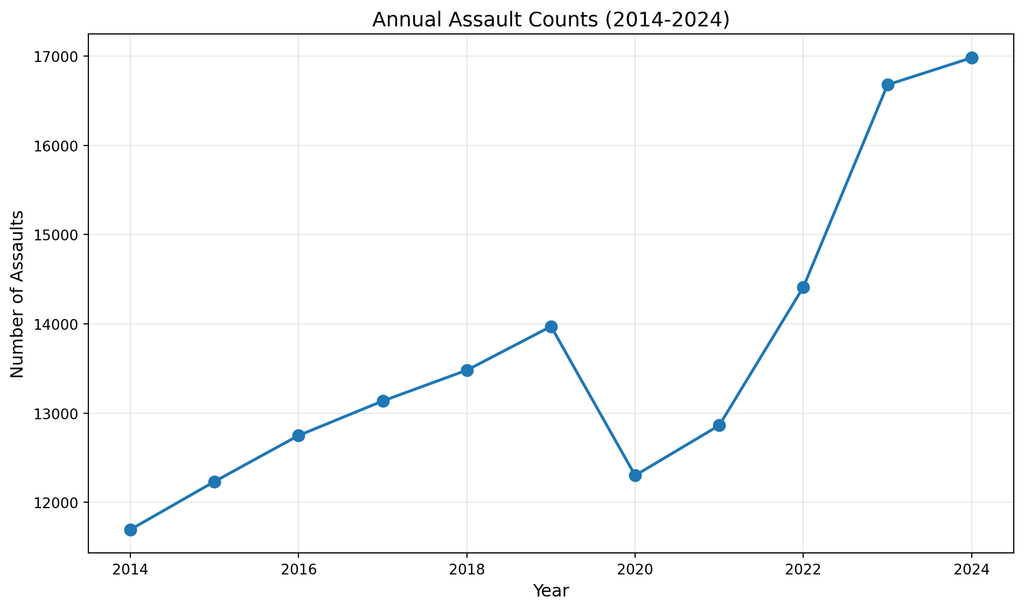

```python
# Create plot of counts over time
plt.figure(figsize=(10, 6))
plt.plot(annual_counts['year'], annual_counts['count'], marker='o', linewidth=2, markersize=8)
plt.xlabel('Year', fontsize=12)
plt.ylabel('Number of Assaults', fontsize=12)
plt.title('Annual Assault Counts (2014-2024)', fontsize=14)
plt.grid(True, alpha=0.3)
plt.tight_layout()
plt.show()
```

```python
# Fit Poisson regression
X_year_const = sm.add_constant(annual_counts['year'])
y_count = annual_counts['count']

poisson_mod = sm.GLM(y_count, X_year_const, family=sm.families.Poisson()).fit()
print(poisson_mod.summary())

# Calculate rate ratio
rate_ratio = np.exp(poisson_mod.params['year'])
print(f"\nRate ratio per 1-year increase: {rate_ratio:.4f}")
```

```
                 Generalized Linear Model Regression Results
==============================================================================
Dep. Variable:                  count   No. Observations:                   11
Model:                            GLM   Df Residuals:                        9
Model Family:                 Poisson   Df Model:                            1
Link Function:                    Log   Scale:                          1.0000
Method:                          IRLS   Log-Likelihood:                -384.11
Date:                Sun, 01 Feb 2026   Deviance:                       643.31
Time:                        19:02:51   Pearson chi2:                     630.
No. Iterations:                     4   Pseudo R-squ. (CS):              1.000
Covariance Type:            nonrobust
==============================================================================
                 coef    std err          z      P>|z|      [0.025      0.975]
------------------------------------------------------------------------------
const        -54.2642      1.651    -32.868      0.000     -57.500     -51.028
year           0.0316      0.001     38.640      0.000       0.030       0.033
==============================================================================

Rate ratio per 1-year increase: 1.0321
```

```python
# Model fit and assumptions check
deviance = poisson_mod.deviance
df_resid = poisson_mod.df_resid

# Calculate likelihood ratio test statistic
llf = poisson_mod.llf
llnull = poisson_mod.llnull
llr = 2 * (llf - llnull)
llr_pvalue = stats.chi2.sf(llr, 1)

diagnostics = pd.DataFrame({
    'Statistical measure': ['Deviance', 'Residual Degrees of Freedom', 'Log-Likelihood Ratio', 'LLR p-value'],
    'Value': [deviance, df_resid, llr, llr_pvalue]
})
display(diagnostics)
```

|  | Statistical measure | Value |
| --- | --- | --- |
| 0 | Deviance | 643.311635 |
| 1 | Residual Degrees of Freedom | 9.000000 |
| 2 | Log-Likelihood Ratio | 1497.589989 |
| 3 | LLR p-value | 0.000000 |

**Summary:**

- Estimated rate ratio per 1-year increase: 1.0321
- Interpretation: For each 1-year increase, the expected count of assaults is multiplied by 1.0321.
- Model fit and assumptions: The deviance is approximately 643. When divided by residual df of 9, we get 71.4, indicating overdispersion and violation of the Poisson model assumption. Results from likelihood ratio test show that the year is a significant predictor of assault counts.
- Evidence of change over time: The LRT shows statistically significant evidence that assault counts change over time. Each 1-year increase is associated with a 3.2% increase in the number of assaults. Confidence intervals should be interpreted with caution due to overdispersion.

## 5. Examine seasonality in crime (7 points)

```python
# Subset to most recent complete year
most_recent_year = crime_analytic['year'].max()
crime_2024 = crime_analytic[crime_analytic['year'] == most_recent_year].copy()
```

```python
# Create season variable
crime_2024['season'] = np.select(
    [
        crime_2024['month'].isin([12, 1, 2]),
        crime_2024['month'].isin([3, 4, 5]),
        crime_2024['month'].isin([6, 7, 8]),
        crime_2024['month'].isin([9, 10, 11])
    ],
    ['Winter', 'Spring', 'Summer', 'Fall']
)
```

```python
# Summary statistics by season
season_counts = crime_2024.groupby('season').size().reset_index(name='count')
display(season_counts)
```

|  | season | count |
| --- | --- | --- |
| 0 | Fall | 4325 |
| 1 | Spring | 4350 |
| 2 | Summer | 4406 |
| 3 | Winter | 3900 |

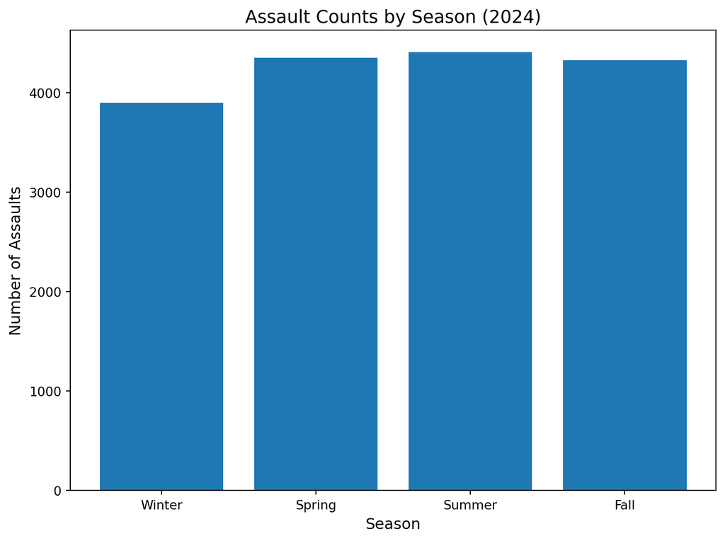

```python
# Plot counts by season
season_order = ['Winter', 'Spring', 'Summer', 'Fall']
season_counts['season'] = pd.Categorical(season_counts['season'], categories=season_order, ordered=True)
season_counts = season_counts.sort_values('season')

plt.figure(figsize=(8, 6))
plt.bar(season_counts['season'].astype(str), season_counts['count'])
plt.xlabel('Season', fontsize=12)
plt.ylabel('Number of Assaults', fontsize=12)
plt.title('Assault Counts by Season (2024)', fontsize=14)
plt.tight_layout()
plt.show()
```

```python
# Chi-square goodness-of-fit test
observed = season_counts['count'].values
expected = np.array([observed.sum() / 4] * 4)

chi2_stat, p_value = stats.chisquare(observed, expected)
std_residuals = (observed - expected) / np.sqrt(expected)

results_df = pd.DataFrame({
    'Season': season_counts['season'].astype(str),
    'Observed': observed,
    'Expected': expected,
    'Difference': observed - expected,
    'Std_Residual': std_residuals
})

display(results_df)
print(f"\nChi-square statistic: {chi2_stat:.4f}")
print(f"P-value: {p_value:.4e}")
```

|  | Season | Observed | Expected | Difference | Std_Residual |
| --- | --- | --- | --- | --- | --- |
| 3 | Winter | 3900 | 4245.25 | -345.25 | -5.298855 |
| 1 | Spring | 4350 | 4245.25 | 104.75 | 1.607690 |
| 2 | Summer | 4406 | 4245.25 | 160.75 | 2.467172 |
| 0 | Fall | 4325 | 4245.25 | 79.75 | 1.223993 |

```
Chi-square statistic: 38.2476
P-value: 2.5050e-08
```

**Summary:**

- Chi-square test results: The Chi-square test is statistically significant (p = 2.5050e-08). So we reject the null hypothesis that the distribution of assault cases is the same across four seasons.
- Interpretation - which seasons have higher/lower counts than expected: Winter has lower counts than expected (standard residual < -5). Summer has higher counts than expected (standard residual > 2).

## 6. Examine seasonality, day vs night (7 points)

```python
# Summarize crime counts by hour
hour_counts = crime_2024.groupby('hour').size().reset_index(name='count')
display(hour_counts)
```

|  | hour | count |
| --- | --- | --- |
| 0 | 0 | 1196 |
| 1 | 1 | 551 |
| 2 | 2 | 506 |
| 3 | 3 | 416 |
| 4 | 4 | 267 |
| 5 | 5 | 234 |
| 6 | 6 | 218 |
| 7 | 7 | 341 |
| 8 | 8 | 517 |
| 9 | 9 | 634 |
| 10 | 10 | 678 |
| 11 | 11 | 750 |
| 12 | 12 | 1062 |
| 13 | 13 | 789 |
| 14 | 14 | 800 |
| 15 | 15 | 1005 |
| 16 | 16 | 925 |
| 17 | 17 | 899 |
| 18 | 18 | 921 |
| 19 | 19 | 836 |
| 20 | 20 | 897 |
| 21 | 21 | 888 |
| 22 | 22 | 856 |
| 23 | 23 | 795 |

```python
# Create day/night indicator
crime_2024['time_of_day'] = np.where(
    (crime_2024['hour'] >= 7) & (crime_2024['hour'] <= 18),
    'Day',
    'Night'
)
```

**Day/night rule:** Day is defined as 7am to 7pm (hours 7-18), Night is all other hours.

```python
# Create season x day/night contingency table
contingency_table = pd.crosstab(crime_2024['season'], crime_2024['time_of_day'])
contingency_table = contingency_table.reindex(season_order)
display(contingency_table)
```

| time_of_day season | Day | Night |
| --- | --- | --- |
| Winter | 2172 | 1728 |
| Spring | 2401 | 1949 |
| Summer | 2314 | 2092 |
| Fall | 2434 | 1891 |

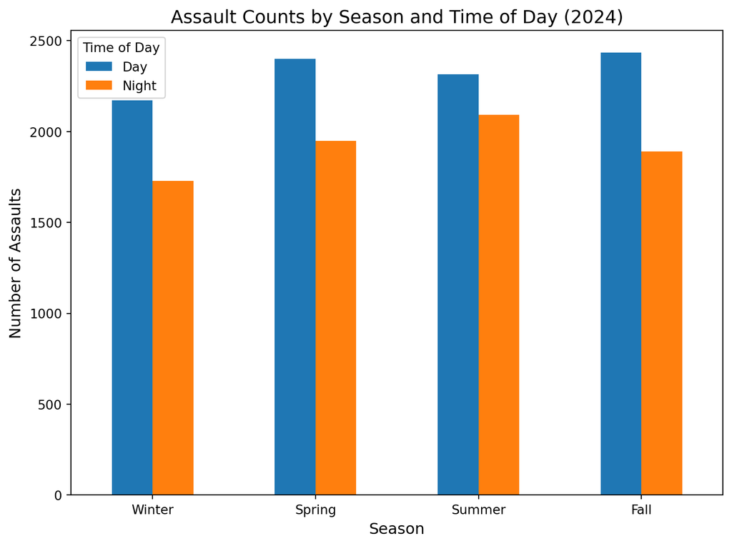

```python
# Visualize contingency table
contingency_table.plot(kind='bar', figsize=(8, 6))
plt.xlabel('Season', fontsize=12)
plt.ylabel('Number of Assaults', fontsize=12)
plt.title('Assault Counts by Season and Time of Day (2024)', fontsize=14)
plt.legend(title='Time of Day')
plt.xticks(rotation=0)
plt.tight_layout()
plt.show()
```

```python
# Chi-square test of independence
chi2, p_value, dof, expected = stats.chi2_contingency(contingency_table)

print(f"Chi-square statistic: {chi2:.4f}")
print(f"P-value: {p_value:.4e}")
print(f"Degrees of freedom: {dof}")

# Calculate standardized residuals
std_residuals = (contingency_table.values - expected) / np.sqrt(expected)
residuals_df = pd.DataFrame(std_residuals,
                            index=contingency_table.index,
                            columns=contingency_table.columns)
print("\nStandardized Residuals:")
display(residuals_df)
```

```
Chi-square statistic: 14.5410
P-value: 2.2540e-03
Degrees of freedom: 3

Standardized Residuals:
```

| time_of_day season | Day | Night |
| --- | --- | --- |
| Winter | 0.675635 | -0.745296 |
| Spring | 0.271197 | -0.299159 |
| Summer | -2.124663 | 2.343726 |
| Fall | 1.230906 | -1.357818 |

**Summary:**

- Chi-square test results: The Chi-square test is significant (p = 2.2540e-03), so we reject the null hypothesis and conclude that the proportion of day vs. night crimes differs significantly across seasons.
- Which seasons look most different: Visually from the barplot, we see that the discrepancy between day and night crimes is the smallest for summer. This is confirmed by standardized residuals: for summer, |standardized residuals| > 2, indicating severe deviations.

## 7. Look at neighbourhood patterns (4 points)

```python
# Which neighbourhoods have more crimes
neighbourhood_counts = crime_2024.groupby('neighbourhood').size().reset_index(name='total_count')
neighbourhood_counts = neighbourhood_counts.sort_values('total_count', ascending=False)
```

```python
# Create table for top 10 neighborhoods with day/night breakdown
top_10_neighbourhoods = neighbourhood_counts.head(10)['neighbourhood'].values

# Filter to top 10 and create day/night breakdown
crime_top10 = crime_2024[crime_2024['neighbourhood'].isin(top_10_neighbourhoods)].copy()

# Remove unused categories from the categorical dtype
crime_top10['neighbourhood'] = crime_top10['neighbourhood'].cat.remove_unused_categories()

neighbourhood_time = crime_top10.groupby(['neighbourhood', 'time_of_day']).size().unstack(fill_value=0)
neighbourhood_time['total_count'] = neighbourhood_time['Day'] + neighbourhood_time['Night']
neighbourhood_time['night_proportion'] = neighbourhood_time['Night'] / neighbourhood_time['total_count']

# Reorder columns and sort by total count
neighbourhood_time = neighbourhood_time[['total_count', 'Day', 'Night', 'night_proportion']]
neighbourhood_time = neighbourhood_time.sort_values('total_count', ascending=False)

display(neighbourhood_time)
```

| time_of_day neighbourhood | total_count | Day | Night | night_proportion |
| --- | --- | --- | --- | --- |
| Mimico-Queensway (160) | 560 | 479 | 81 | 0.144643 |
| Downtown Yonge East (168) | 401 | 217 | 184 | 0.458853 |
| St Lawrence-East Bayfront-The Islands (166) | 366 | 186 | 180 | 0.491803 |
| Yonge-Bay Corridor (170) | 358 | 215 | 143 | 0.399441 |
| Moss Park (73) | 334 | 184 | 150 | 0.449102 |
| Kensington-Chinatown (78) | 317 | 153 | 164 | 0.517350 |
| Wellington Place (164) | 304 | 107 | 197 | 0.648026 |
| Annex (95) | 292 | 130 | 162 | 0.554795 |
| West Hill (136) | 274 | 155 | 119 | 0.434307 |
| Church-Wellesley (167) | 248 | 136 | 112 | 0.451613 |

```python
display(neighbourhood_time.describe())
```

| time_of_day | total_count | Day | Night | night_proportion |
| --- | --- | --- | --- | --- |
| count | 10.000000 | 10.000000 | 10.000000 | 10.000000 |
| mean | 345.400000 | 196.200000 | 149.200000 | 0.454993 |
| std | 88.074716 | 105.694318 | 36.230129 | 0.130110 |
| min | 248.000000 | 107.000000 | 81.000000 | 0.144643 |
| 25% | 295.000000 | 140.250000 | 125.000000 | 0.438005 |
| 50% | 325.500000 | 169.500000 | 156.000000 | 0.455233 |
| 75% | 364.000000 | 207.750000 | 176.000000 | 0.510963 |
| max | 560.000000 | 479.000000 | 197.000000 | 0.648026 |

**Interpretation of top 10 neighborhoods:**

- Total count: the largest total count of assaults in 2024 is 560 and occurs in Mimico-Queensway.
- Night proportion: Most neighborhoods have roughly equal day vs night counts, so the night proportion is usually within 0.4 and 0.6. However, for Mimico-Queensway, only 14% of assaults occur during the night. This is a residential area. By contrast, in Wellington Place, 65% of assaults occur during the night. This is an area with entertainment facilities.

The standard deviation of night proportion is 0.13.

## 8. Create a map (4 points)

```python
# Aggregate crime data by neighbourhood
crime_map_data = crime_2024.dropna(subset=['latitude', 'longitude', 'neighbourhood']).copy()

# Group by neighbourhood and calculate mean coordinates and crime counts
neighbourhood_summary = crime_map_data.groupby('neighbourhood').agg({
    'latitude': 'mean',
    'longitude': 'mean',
    'time_of_day': 'count'
}).rename(columns={'time_of_day': 'total_count'}).reset_index()

# Calculate day and night counts separately
day_counts = crime_map_data[crime_map_data['time_of_day'] == 'Day'].groupby('neighbourhood').size()
night_counts = crime_map_data[crime_map_data['time_of_day'] == 'Night'].groupby('neighbourhood').size()

neighbourhood_summary['day_count'] = neighbourhood_summary['neighbourhood'].map(day_counts).fillna(0)
neighbourhood_summary['night_count'] = neighbourhood_summary['neighbourhood'].map(night_counts).fillna(0)

# Create base map
m = folium.Map(
    location=[neighbourhood_summary['latitude'].mean(), neighbourhood_summary['longitude'].mean()],
    zoom_start=11,
    tiles='CartoDB positron'
)

# Add circle markers for each neighbourhood
for _, r in neighbourhood_summary.iterrows():
    folium.CircleMarker(
        location=[r['latitude'], r['longitude']],
        radius=r['total_count'] / 20,
        fill=True,
        fill_opacity=0.6,
        opacity=0.8,
        color='darkred',
        fill_color='red',
        popup=f"{r['neighbourhood']}<br>Total: {r['total_count']:.0f}<br>Day: {r['day_count']:.0f}<br>Night: {r['night_count']:.0f}"
    ).add_to(m)

m
```

Make this Notebook Trusted to load map: File -> Trust Notebook

[interactive chart not shown]

**Summary:**

- Spatial patterns observed: The maps shows that assault crimes are concentrated near lake shore instead of evenly distributed across the city. Since we are grouping by neighborhoods, we see that the top 10 neighborhoods e.g., Mimico-Queensway correspond to larger circles on the map.